# Opracowanie mapy Polski z wykorzystaniem danych z www.geoportal.gov.pl i pakietu `ggplot2`

Anna Kozak

2025-03-16

## Dane z Głównego Urzędu Geodezji i Kartografii

Pierwszym elementem przygotowania mapy Polski jest pobranie danych opisujących granice państwa, granice województw, granice powiatów lub gmin. Pliki te dostępne są pod adresem https://www.geoportal.gov.pl/pl/dane/panstwowy-rejestr-granic-prg/. Korzystając z www.geoportal.gov.pl można wybrać tylko potrzebny podzbiór danych, natomiast ze strony *Państwowy Rejestr Granic (PRG)* na końcu strony są gotowe do pobrania pliki spakowane w .zip.

## Rozpakowanie danych

Pobrane dane należy rozpakować. Folder zawiera granice dla państwa/województw/powiatów .. w różnych rozszerzeniach. Interesującym plikiem do rysowania granic w pakiecie `ggplot2` jest tak zwany plik *shapefile* (.shp).

> Shapefile – format zapisu danych przestrzennych. Zapis geometrii danego elementu przechowywany jest jako zbiór współrzędnych wektora. Format opracowany przez firmę ESRI jako otwarty standard i wykorzystywany w systemach informacji geograficznej (GIS) *Żródło: [Wikipedia](https://pl.wikipedia.org/wiki/Shapefile)*

## Wczytanie danych z plików .shp

Potrzebujemy pakietu `sf`. Należy go zainstalować.

```r
install.packages("sf")
```

Uruchomienie potrzebych pakietów.

```r
library(sf)
library(ggplot2)
library(dplyr)
```

Wczytanie pliku z granicami na przykładzie granic powiatów. W funkcji `st_read` należy podać ścieżkę do pliku .shp zawierającego interesujące nas granice. Argument `quiet` decyduje czy są wypisywane dodatkowe informacje o wczytanym pliku.

```r
granice_powiatow <-  st_read("mapa/A02_Granice_powiatow.shp", quiet = TRUE)
```

Podgląd wczytanych danych.

```r
head(granice_powiatow)
```

```
## Simple feature collection with 6 features and 34 fields
## Geometry type: MULTIPOLYGON
## Dimension:     XY
## Bounding box:  xmin: 19.25921 ymin: 49.8872 xmax: 23.12841 ymax: 52.99028
## Geodetic CRS:  ETRS89
##   JPT_SJR_KO JPT_POWIER JPT_KOD_JE                    JPT_NAZWA_ JPT_ORGAN_
## 1        POW      54830       1815 powiat ropczycko-sędziszowski       <NA>
## 2        POW      77248       1410                powiat łosicki       <NA>
## 3        POW      85203       1427              powiat sierpecki       <NA>
## 4        POW      61487       1404            powiat gostyniński       <NA>
## 5        POW      36700       1405              powiat grodziski       <NA>
## 6        POW     139425       0611               powiat łukowski       <NA>
##   JPT_JOR_ID  WERSJA_OD WERSJA_DO   WAZNY_OD WAZNY_DO JPT_KOD__1 JPT_NAZWA1
## 1      13415 2012-09-26      <NA> 2012-09-26     <NA>       <NA>       <NA>
## 2      13409 2012-09-26      <NA> 2012-09-26     <NA>       <NA>       <NA>
```

[output cut: 39 more lines]

## Rysowanie mapy z wykorzystaniem funkcji `geom_sf()`

Przykładowe wykorzystanie funkcji `geom_sf()`.

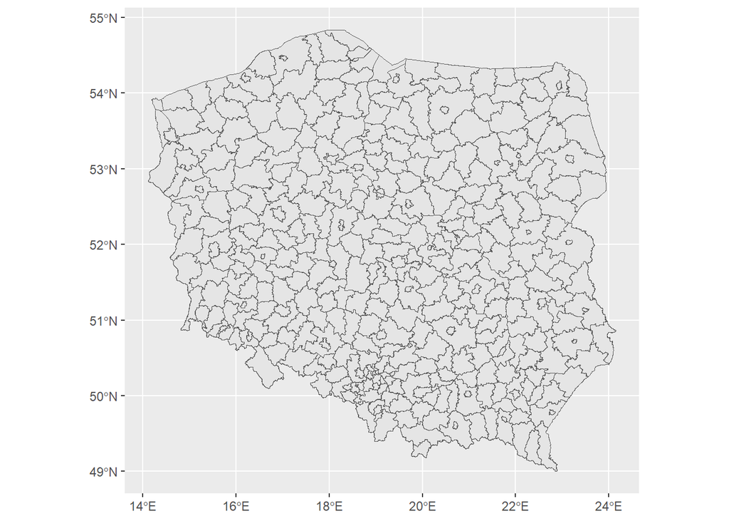

```r
ggplot(data = granice_powiatow) +
  geom_sf()
```

Wykorzystując argumenty funkcji `geom_sf()` możemy zmieniać kolor granic oraz wypełnienie.

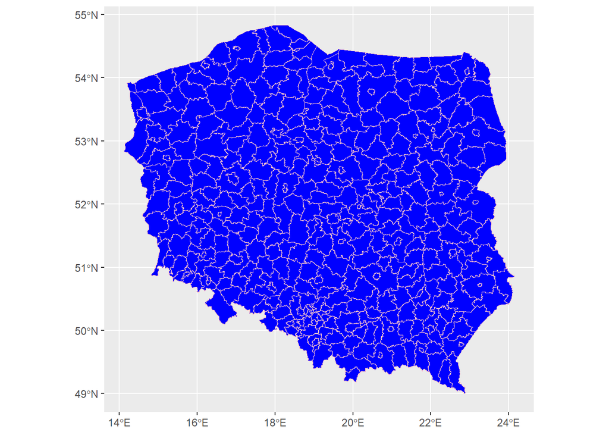

```r
ggplot(data = granice_powiatow) +
  geom_sf(color = "pink", fill = "blue")
```

Zmieniając ustawienia stylu wykresu możemy pozbyć się zbędnych ozdobników. Funkcja `theme_void()` zostawia tylko mapę pomijając współrzędne geograficzne.

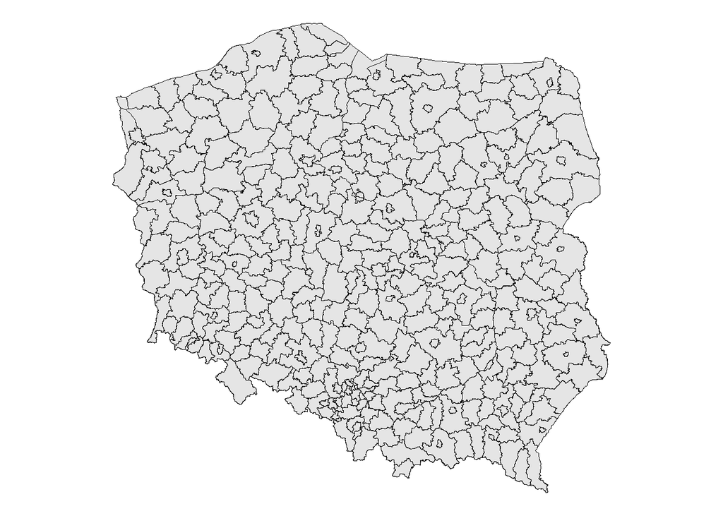

```r
ggplot(data = granice_powiatow) +
  geom_sf(color = "black") +
  theme_void()
```

## Wypełnianie mapy

W tym celu należy pozyskać dane w odpowiednim podziale na wybrane granice.

Przykładowe dane dotyczące zdawalności egzaminów w 2023 roku https://bdl.stat.gov.pl/BDL/start, kategoria szkolnictwo (K20), grupa zdawalność egzaminów (G500).

Wczytanie danych.

```r
#Części dziesiętne są oddzielone przez ",", należy zmienić na ".".
dane <- read.csv("mapa/SZKO_3193_CTAB_20250316153954.csv", sep = ";", dec = ",")
```

Pobranie danych o województwach.

```r
wojewodztwa <- st_read("mapa/A01_Granice_wojewodztw.shp", quiet = TRUE)
```

W kolejnym kroku należy połączyć obie tabele, kluczem jest nazwa województwa, ale w jednej tabeli są wymienione małymi literami, w drugiej wielkimi. Należy uspójnić.

```r
#Zmiana wielkich liter na małe.
dane$Nazwa <- tolower(dane$Nazwa)
```

Połączenie tabel i podstawowy wykres ze wskaźnikiem.

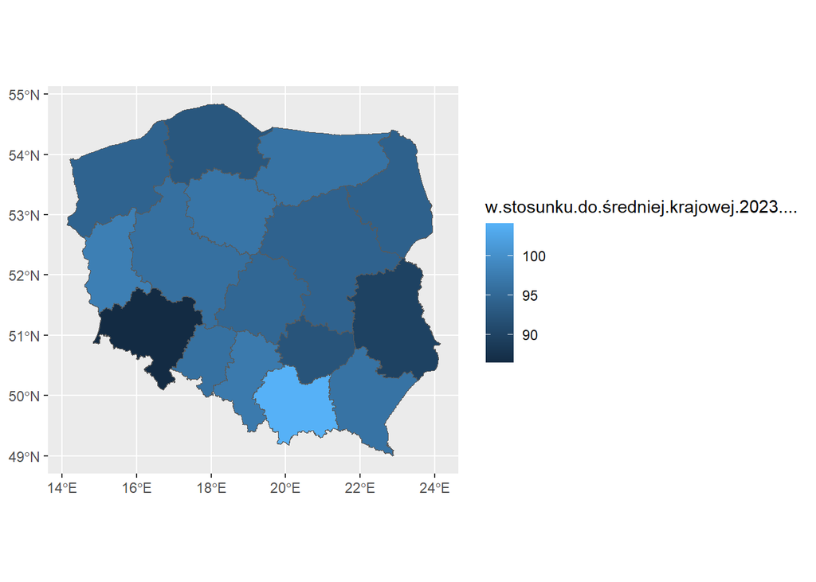

```r
wojewodztwa %>%
  left_join(dane, by = join_by(JPT_NAZWA_ == Nazwa)) %>%
  ggplot() +
  geom_sf(aes(fill = w.stosunku.do.średniej.krajowej.2023....))
```

Wykres po poprawkach.

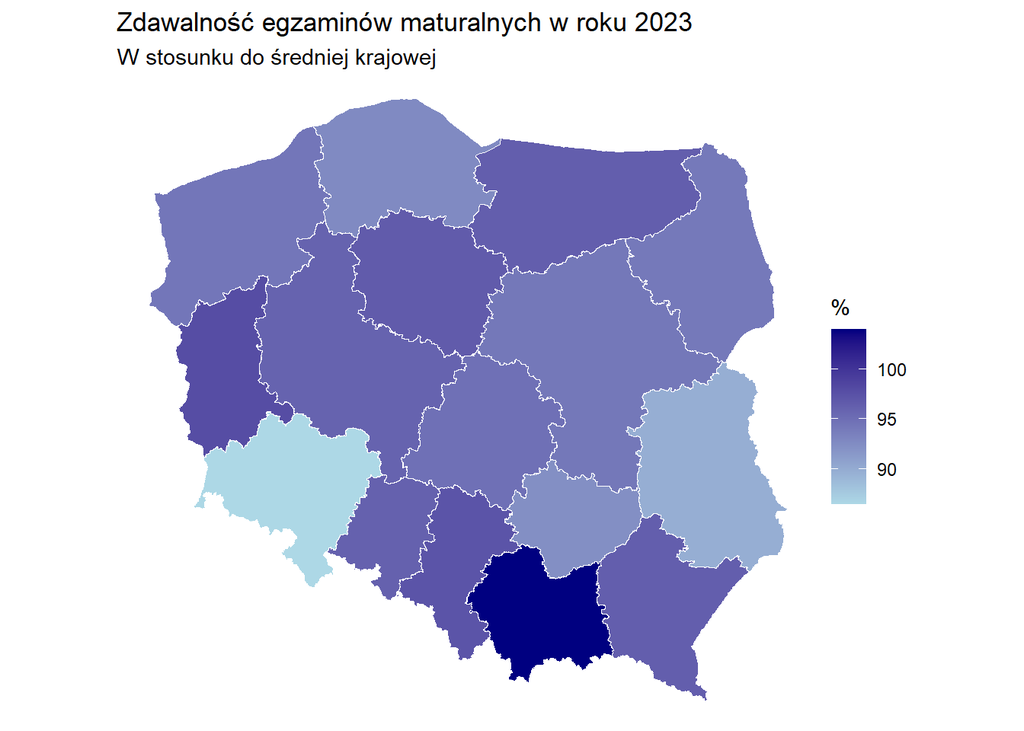

```r
wojewodztwa %>%
  left_join(dane, by = join_by(JPT_NAZWA_ == Nazwa)) %>%
  ggplot() +
  geom_sf(aes(fill = w.stosunku.do.średniej.krajowej.2023....),
          color = "white") +
  theme_void() +
  scale_fill_gradient(low = "lightblue", high = "navy") +
  labs(title = "Zdawalność egzaminów maturalnych w roku 2023",
       subtitle = "W stosunku do średniej krajowej",
       fill = "%")
```